# Statistical Inference - Part 2 Basic inferential data analysis

Andrey Budish

March 31, 2017

### Overview

The purpose of this project is to analyze ToothGrowth data in the R datasets package. I will perform basic exploratory data analysis of this data, calculate confidence intervals and perform hypothesis tests to compare tooth growth by supp and dose.

### Loading the data

Let’s Load ToothGrowth data:

```r
library(datasets)
data("ToothGrowth")
```

### Basic exploratory data analysis

Let’s take a look at the data:

```r
head(ToothGrowth)
```

```
##    len supp dose
## 1  4.2   VC  0.5
## 2 11.5   VC  0.5
## 3  7.3   VC  0.5
## 4  5.8   VC  0.5
## 5  6.4   VC  0.5
## 6 10.0   VC  0.5
```

```r
str(ToothGrowth)
```

```
## 'data.frame':    60 obs. of  3 variables:
##  $ len : num  4.2 11.5 7.3 5.8 6.4 10 11.2 11.2 5.2 7 ...
##  $ supp: Factor w/ 2 levels "OJ","VC": 2 2 2 2 2 2 2 2 2 2 ...
##  $ dose: num  0.5 0.5 0.5 0.5 0.5 0.5 0.5 0.5 0.5 0.5 ...
```

From ?ToothGrowth we can read the description and format of the data.

*Description*  
The response is the length of odontoblasts (cells responsible for tooth growth) in 60 guinea pigs. Each animal received one of three dose levels of vitamin C (0.5, 1, and 2 mg/day) by one of two delivery methods, (orange juice or ascorbic acid (a form of vitamin C and coded as VC).

*Format*  
A data frame with 60 observations on 3 variables.

[,1] len numeric Tooth length  
[,2] supp factor Supplement type (VC or OJ).  
[,3] dose numeric Dose in milligrams/day

Since we have 3 levels of vitamin C dosage, let’s change dose to the factor variable:

```r
ToothGrowth$dose <- as.factor(ToothGrowth$dose)
```

To count how many observations of each of the unique combinations of supplement/dosage let’s make a relevant table

```r
table(ToothGrowth$supp, ToothGrowth$dose)
```

```
##
##      0.5  1  2
##   OJ  10 10 10
##   VC  10 10 10
```

We can see that we have 10 observations for each of the supplement/dosage group.

Let’s built a boxplot which will show changes of the teeth length across supplement/dosage groups:

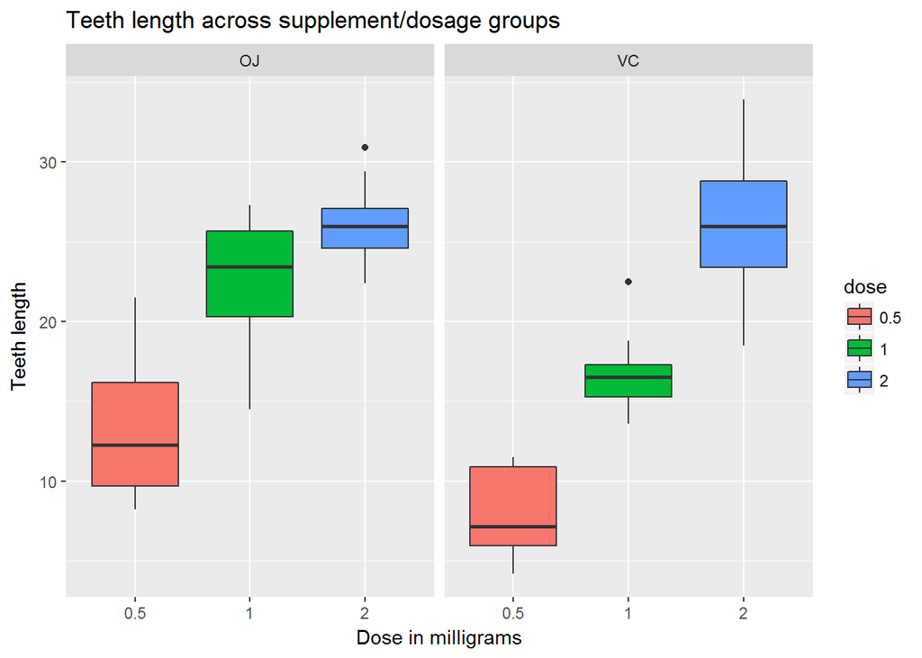

```r
library(ggplot2)
p <-  ggplot(ToothGrowth,
               aes(x=dose, y=len, fill=dose))
p + geom_boxplot(notch = FALSE) + facet_grid(. ~ supp) +
        scale_x_discrete("Dose in milligrams") +
        scale_y_continuous("Teeth length") +
        ggtitle("Teeth length across supplement/dosage groups")
```

### Comparing tooth growth by supp and dose using hypothesis testing

From the plot above we can make a few assumptions:  
**1. Increasing the dose levels increases the length of teeth.**  
**2. Ascorbic acid and orange juice has different impact on tooth growth at the same dose levels**

Let us test those assumptions.

**1.1 Testing orange juice (OJ) influence on the teeth length between different dose levels:**

```r
# create 3 data frames for each of the dose levels of orange juice that contain relevant tooth length
len_OJ_0.5 <- subset(ToothGrowth, supp == "OJ" & dose == "0.5", select = len)
len_OJ_1 <- subset(ToothGrowth, supp == "OJ" & dose == "1", select = len)
len_OJ_2 <- subset(ToothGrowth, supp == "OJ" & dose == "2", select = len)
```

```r
# t-test between 1 and 0.5 milligrams/day dose of orange juice
t.test(len_OJ_1 - len_OJ_0.5, paired = FALSE, var.equal = FALSE, alternative = "greater")$p.value
```

```
## [1] 0.00121757
```

```r
# t-test between 2 and 1 milligrams/day dose of orange juice
t.test(len_OJ_2 - len_OJ_1, paired = FALSE, var.equal = FALSE, alternative = "greater")$p.value
```

```
## [1] 0.04191956
```

- **For both tests p-values are less than 0.05 which shows that increasing the dose levels of orange juice increases the length of teeth.**

**1.2 Testing ascorbic acid (VC) influence on the teeth length between different dose levels:**

```r
# create 3 data frames for each of the dose levels of ascorbic acid that contain relevant tooth length
len_VC_0.5 <- subset(ToothGrowth, supp == "VC" & dose == "0.5", select = len)
len_VC_1 <- subset(ToothGrowth, supp == "VC" & dose == "1", select = len)
len_VC_2 <- subset(ToothGrowth, supp == "VC" & dose == "2", select = len)
```

```r
# t-test between 1 and 0.5 milligrams/day dose of ascorbic acid
t.test(len_VC_1 - len_VC_0.5, paired = FALSE, var.equal = FALSE, alternative = "greater")$p.value
```

```
## [1] 8.575825e-05
```

```r
# t-test between 2 and 1 milligrams/day dose of ascorbic acid
t.test(len_VC_2 - len_VC_1, paired = FALSE, var.equal = FALSE, alternative = "greater")$p.value
```

```
## [1] 0.0002323975
```

- **For both tests p-values are less than 0.05 which shows that increasing the dose levels of ascorbic acid increases the length of teeth**.

**2 Testing difference of impact on tooth grows between orange juice(OJ) and ascorbic acid(VC) at the same dose levels**

The null hypothesis will state that there is no difference between tooth length means and alternative hypothesis - that orange juice has bigger effect on tooth length than ascorbic acid at the same dose levels.

```r
# t-test between orange juice and ascorbic acid, 0.5 milligrams dose
supp_test0.5 <- t.test(len_OJ_0.5 - len_VC_0.5, paired = FALSE, var.equal = FALSE, alternative = "greater")

# t-test between orange juice and ascorbic acid, 1 milligram dose
supp_test1 <- t.test(len_OJ_1 - len_VC_1, paired = FALSE, var.equal = FALSE, alternative = "greater")

# t-test between orange juice and ascorbic acid, 2 milligrams dose
supp_test2 <- t.test(len_OJ_2 - len_VC_2, paired = FALSE, var.equal = FALSE, alternative = "greater")

# table of p-values
data.frame("p-value"= c(supp_test0.5$p.value, supp_test1$p.value, supp_test2$p.value),
           row.names = c("OJ > VC (0.5 milligrams)", "OJ > VC (1 milligram)", "OJ > VC (2 milligrams"))
```

```
##                              p.value
## OJ > VC (0.5 milligrams) 0.007736024
## OJ > VC (1 milligram)    0.004114624
## OJ > VC (2 milligrams    0.516521648
```

- **For 0.5 and 1 milligram, p-value is smaller than 0.05, which shows that orange juice has bigger impact on tooth length than ascorbic acid.**
- **For 2 milligram - p-value is more than 0.05, which shows that there is no difference of impact on tooth grows between orange juice and ascorbic acid.**

### Conclusions

Based on the above t-tests we can conclude.  
**1. Increasing the dose levels increases the length of teeth.**  
**2. At 0.5 and 1 milligram dosages orange juice has greater impact on tooth growth than ascorbic acid.**  
**3. At 2 milligram dosage there is no statistical difference between supplement methods.**